# ConsensusMetaDA: an R Package for consensus-based differential abundance analysis of metagenomic data.

Manoharan Kumar, Matt Field

Last modified: 2025-07-23. Compiled: 2025-08-28

# 1 Introduction to ConsensusMetaDA

ConsensusMetaDA is an R package for microbiome analysis using multiple algorithms - reaching consensus. No one tool perform best DA anlayes on metaganome data. Hence it needs a consensus approach to obtain more robust differential abundant microbiome. ConsensusMetaDA helps achieve this using five popularly used tools. ConsensusMetaDA uses popular biom format and samples table as input to perform DA along with it generates standard microbiome visualization plots such as Alpha Diversity, Beta Diversity, Rarefaction curve, Bidirectional plot and Scale plot at various taxa levels.

ConsensusMetaDA is simplified into two functions:

- `build_OTU_counts()` generate an phyloseq object that contain OTU reads counts (using biome, sample counts and taxa files)
- `OTU_multi_DA()` perform DA analysis (all possible pairwise comparisons)

Below the core functionality of ConsensusMetaDA as well as how to plot results using the OTU_plots function.

```r
# install supporting packages

# ADAPT R package requires R version 4.4 hence need all R updated to R v4.4.2

# One line per package
# if (!require("ggplot2", quietly = TRUE)) install.packages("ggplot2")
# if (!require("BiocManager", quietly = TRUE)) install.packages("BiocManager")
# if (!require("phyloseq", quietly = TRUE)) BiocManager::install("phyloseq")
# if (!require("DESeq2", quietly = TRUE)) BiocManager::install("DESeq2")
# if (!require("ALDEx2", quietly = TRUE)) BiocManager::install("ALDEx2")
# if (!require("edgeR", quietly = TRUE)) BiocManager::install("edgeR")
# if (!require("ADAPT", quietly = TRUE)) BiocManager::install("ADAPT")
# if (!require("metagenomeSeq", quietly = TRUE)) BiocManager::install("metagenomeSeq")
#
# if (!require("ConsensusMetaDA", quietly = TRUE)) {
#   if (!require("remotes", quietly = TRUE)) install.packages("remotes")
#   remotes::install_github("kmanoharan01/ConsensusMetaDA")
# }
```

## 1.1 Load Libraries

Begin by first installing and loading the ConsensusMetaDA library.

```r
# Load the packages
library(ggplot2)
library(phyloseq)
library(DESeq2)
library(ALDEx2)
library(edgeR)
library(metagenomeSeq)
library(ADAPT)


# load ConsensusMetaDA

library(ConsensusMetaDA)
```

# 2 ConsensusMetaDA examples

```r
library(ADAPT)

data("ecc_saliva")

otu_mat <- as(otu_table(ecc_saliva), "matrix")
sample_df <- as(sample_data(ecc_saliva), "data.frame")
tax_mat <- as(tax_table(ecc_saliva), "matrix")

#otu_final <- data.frame(sampleID = rownames(otu_mat), otu_mat)

#write.table(otu_mat, file = "ecc_saliva_Otu.txt",  col.names = TRUE, sep = "\t", quote = FALSE)

#write.table(sample_df, file = "ecc_saliva_sample_table.txt", col.names = TRUE, sep = "\t", quote = FALSE)

#write.table(tax_mat, file = "ecc_saliva_tax_table.txt", col.names = TRUE, sep = "\t", quote = FALSE)

################

#system("module load python3/3.10.4")

#system("~/.local/bin/biom convert -i ecc_saliva_Otu.txt   -o ecc_saliva_Otu.biom --table-type='OTU table' --to-json")

ecc_saliva_biom <- "../inst//extdata/ecc_saliva_Otu.biom"

ecc_saliva_sample_table <- "../inst//extdata/ecc_saliva_sample_table.txt"

ecc_saliva_tax <- tax_mat

taxa_names(tax_mat)
```

```r
#tax_mat_test <- tax_table(tax_mat)
```

# 3 Building a phyloseq format

This function takes inputs such as biom file, sample list, and taxa information and creates a build_OTU_count object. To build a ConsensusMetaDA requires a biom file and sample grouping table with location path. Taxa level by accepts 7 taxa level. This function is incorporated utilizing the phyloseq (v1.50.0) package (McMurdie & Holmes, 2013). It also can take filtering parameters such as abundance_threshold, prevalence_threshold, rarity_threshold and variance_threshold

This generates phyloseq object that stores all relevant information for performing differential abundance analysis. build_OTU_counts() allows users to build a phyloseq object by simply providing 1) a biom file, 2) a sample file, 3) a taxa and 4) filtering option. Below we will use biom file and sample table file as an example for creating a summarized experiment:

```r
## build
ecc_saliva_build_OTU_counts <- build_OTU_counts(ecc_saliva_biom,
                                                 ecc_saliva_sample_table,
                                                 ecc_saliva_tax,
                                                 abundance_threshold = 10,
                                                 prevalence_threshold = 0.1,
                                                 rarity_threshold = 0,
                                                 variance_threshold = 0
)

ecc_saliva_build_OTU_counts
```

```
## phyloseq-class experiment-level object
## otu_table()   OTU Table:         [ 114 taxa and 161 samples ]
## sample_data() Sample Data:       [ 161 samples by 3 sample variables ]
## tax_table()   Taxonomy Table:    [ 114 taxa by 7 taxonomic ranks ]
```

## 3.1 filtering rarity format

With rarity filter one can provide numeric values and filter based on this value.

```r
ecc_saliva_build_OTU_counts <- build_OTU_counts(ecc_saliva_biom,
                                                 ecc_saliva_sample_table,
                                                 ecc_saliva_tax,
                                                 abundance_threshold = 0,
                                                 prevalence_threshold = 0,
                                                 rarity_threshold = 0.1,
                                                 variance_threshold = 0
)

ecc_saliva_build_OTU_counts
```

```
## phyloseq-class experiment-level object
## otu_table()   OTU Table:         [ 244 taxa and 161 samples ]
## sample_data() Sample Data:       [ 161 samples by 3 sample variables ]
## tax_table()   Taxonomy Table:    [ 244 taxa by 7 taxonomic ranks ]
```

## 3.2 filtering abundance format

With abundance filter one can provide numeric values and filter based on this value.

```r
ecc_saliva_build_OTU_counts <- build_OTU_counts(ecc_saliva_biom,
                                                 ecc_saliva_sample_table,
                                                 ecc_saliva_tax,
                                                 abundance_threshold = 10,
                                                 prevalence_threshold = 0,
                                                 rarity_threshold = 0,
                                                 variance_threshold = 0
)

ecc_saliva_build_OTU_counts
```

```
## phyloseq-class experiment-level object
## otu_table()   OTU Table:         [ 238 taxa and 161 samples ]
## sample_data() Sample Data:       [ 161 samples by 3 sample variables ]
## tax_table()   Taxonomy Table:    [ 238 taxa by 7 taxonomic ranks ]
```

## 3.3 filtering prevalence format

With prevalence filter one can provide numeric values and filter based on this value.

```r
ecc_saliva_build_OTU_counts <- build_OTU_counts(ecc_saliva_biom,
                                                 ecc_saliva_sample_table,
                                                 ecc_saliva_tax,
                                                 abundance_threshold = 10,
                                                 prevalence_threshold = 0.1,
                                                 rarity_threshold = 0,
                                                 variance_threshold = 0
)

ecc_saliva_build_OTU_counts
```

```
## phyloseq-class experiment-level object
## otu_table()   OTU Table:         [ 114 taxa and 161 samples ]
## sample_data() Sample Data:       [ 161 samples by 3 sample variables ]
## tax_table()   Taxonomy Table:    [ 114 taxa by 7 taxonomic ranks ]
```

## 3.4 filtering variance format

With variance filter one can provide numeric values and filter based on this value.

```r
ecc_saliva_build_OTU_counts <- build_OTU_counts(ecc_saliva_biom,
                                                 ecc_saliva_sample_table,
                                                 ecc_saliva_tax,
                                                 abundance_threshold = 0,
                                                 prevalence_threshold = 0,
                                                 rarity_threshold = 0,
                                                 variance_threshold = 0.2
)

ecc_saliva_build_OTU_counts
```

```
## phyloseq-class experiment-level object
## otu_table()   OTU Table:         [ 241 taxa and 161 samples ]
## sample_data() Sample Data:       [ 161 samples by 3 sample variables ]
## tax_table()   Taxonomy Table:    [ 241 taxa by 7 taxonomic ranks ]
```

# 4 Performing differential abundance

```r
## build
ecc_saliva_build_OTU_counts <- build_OTU_counts(ecc_saliva_biom,
                                                 ecc_saliva_sample_table,
                                                 ecc_saliva_tax,
                                                 abundance_threshold = 10,
                                                 prevalence_threshold = 0.1,
                                                 rarity_threshold = 0,
                                                 variance_threshold = 0
)

ecc_saliva_build_OTU_counts
```

```
## phyloseq-class experiment-level object
## otu_table()   OTU Table:         [ 114 taxa and 161 samples ]
## sample_data() Sample Data:       [ 161 samples by 3 sample variables ]
## tax_table()   Taxonomy Table:    [ 114 taxa by 7 taxonomic ranks ]
```

```r
## Perform DA

ecc_saliva_DA <- OTUs_multi_DA(ecc_saliva_build_OTU_counts)
```

```
## Running comparison: Control_vs_Case
## [1] "Running EdgeR Analysis..."
```

```
## Comparison of groups:  Control-Case
##           logFC
## ASV71 -4.508225
## [1] "EdgeR: "
## [1] "Case"    "Control"
## [1] "Running DESeq2 Analysis..."
```

[output not shown]

[output cut: 32 more lines]

```
## |------------(25%)----------(50%)----------(75%)----------|
```

```
## [1] "Running ADAPT Analysis..."
## Choose 'Control' as the baseline condition
## 114 taxa and 161 samples being analyzed...
## Selecting Reference Set... 28 taxa selected as reference
## 25 differentially abundant taxa detected
## Differential abundance analysis for Age_Group (Case VS Control)
## 114 taxa and 161 samples analyzed
## 28 taxa are selected as reference and 25 taxa are differentially abundant
## [1] "Running metagenomeSeq Analysis..."
```

```
##       Taxa logFC_edgeR   pval_edgeR   padj_edgeR logFC_DESeq2  pval_DESeq2
## 1    ASV71 -4.50822511 9.104706e-18 1.037937e-15  -3.78227448 0.0096930690
## 2   ASV119  3.18160639 2.960260e-15 1.687348e-13   1.86393166 0.2345417534
## 3    ASV20 -3.41914390 1.182613e-11 4.493931e-10  -2.64812492 0.0005973165
## 4    ASV83 -2.41849556 1.807397e-10 5.151081e-09  -2.01072410 0.0085829207
## 5    ASV48 -2.11688157 6.527371e-10 1.488241e-08  -2.46306777 0.0210705622
## 6     ASV8 -1.74170343 2.417508e-08 4.593266e-07  -1.22413635 0.0000113229
## 7   ASV269 -1.76653274 3.285400e-08 5.350508e-07  -1.36149274 0.3139370959
## 8    ASV63 -2.39641631 4.251261e-08 6.058047e-07  -3.05146068 0.0659849512
## 9    ASV47 -2.33457929 5.850860e-08 7.411089e-07  -2.00992335 0.0032610045
## 10  ASV152 -1.72569825 3.233611e-07 3.384384e-06  -1.78034818 0.0690661827
## 11   ASV30 -2.09604235 3.265634e-07 3.384384e-06  -1.59688362 0.0072694146
## 12  ASV164 -1.39279500 1.010899e-05 9.603542e-05  -1.78676220 0.1314209396
## 13  ASV124 -1.23179451 2.704664e-05 2.371782e-04  -1.75168310 0.0168932598
## 14   ASV33 -1.78713626 3.232751e-05 2.632383e-04  -0.26059295 0.7639459293
```

[output cut: 358 more lines]

```
## Running comparison: Case_vs_Control
## [1] "Running EdgeR Analysis..."
```

```
## Comparison of groups:  Control-Case
##           logFC
## ASV71 -4.508225
## [1] "EdgeR: "
## [1] "Case"    "Control"
## [1] "Running DESeq2 Analysis..."
```

[output not shown]

[output cut: 32 more lines]

```
## |------------(25%)----------(50%)----------(75%)----------|
```

```
## [1] "Running ADAPT Analysis..."
## Choose 'Control' as the baseline condition
## 114 taxa and 161 samples being analyzed...
## Selecting Reference Set... 28 taxa selected as reference
## 25 differentially abundant taxa detected
## Differential abundance analysis for Age_Group (Case VS Control)
## 114 taxa and 161 samples analyzed
## 28 taxa are selected as reference and 25 taxa are differentially abundant
## [1] "Running metagenomeSeq Analysis..."
```

```
##       Taxa logFC_edgeR   pval_edgeR   padj_edgeR logFC_DESeq2  pval_DESeq2
## 1    ASV71 -4.50822511 9.104706e-18 1.037937e-15   3.78227448 0.0096930690
## 2   ASV119  3.18160639 2.960260e-15 1.687348e-13  -1.86393166 0.2345417534
## 3    ASV20 -3.41914390 1.182613e-11 4.493931e-10   2.64812492 0.0005973165
## 4    ASV83 -2.41849556 1.807397e-10 5.151081e-09   2.01072410 0.0085829207
## 5    ASV48 -2.11688157 6.527371e-10 1.488241e-08   2.46306777 0.0210705622
## 6     ASV8 -1.74170343 2.417508e-08 4.593266e-07   1.22413635 0.0000113229
## 7   ASV269 -1.76653274 3.285400e-08 5.350508e-07   1.36149274 0.3139370959
## 8    ASV63 -2.39641631 4.251261e-08 6.058047e-07   3.05146068 0.0659849512
## 9    ASV47 -2.33457929 5.850860e-08 7.411089e-07   2.00992335 0.0032610045
## 10  ASV152 -1.72569825 3.233611e-07 3.384384e-06   1.78034818 0.0690661827
## 11   ASV30 -2.09604235 3.265634e-07 3.384384e-06   1.59688362 0.0072694146
## 12  ASV164 -1.39279500 1.010899e-05 9.603542e-05   1.78676220 0.1314209396
## 13  ASV124 -1.23179451 2.704664e-05 2.371782e-04   1.75168310 0.0168932598
## 14   ASV33 -1.78713626 3.232751e-05 2.632383e-04   0.26059295 0.7639459293
```

[output cut: 358 more lines]

Running `OTUs_multi_DA()` will perform DA analysis on all possible pairs of “groups” and save these results as a simple list of “merged” - being the merged results of “DESeq2”, “metagenomeSeq”, “edgeR”, “ALDEx2” and “ADAPT” into one table, as well as the latter five as objects independently. The data frame is sorted by the `rank_sum`. The following columns are included:

## 4.1 UpSet Plot from Differential abundance

UpSet plot is plotted for each differential abundance comparison respectively.

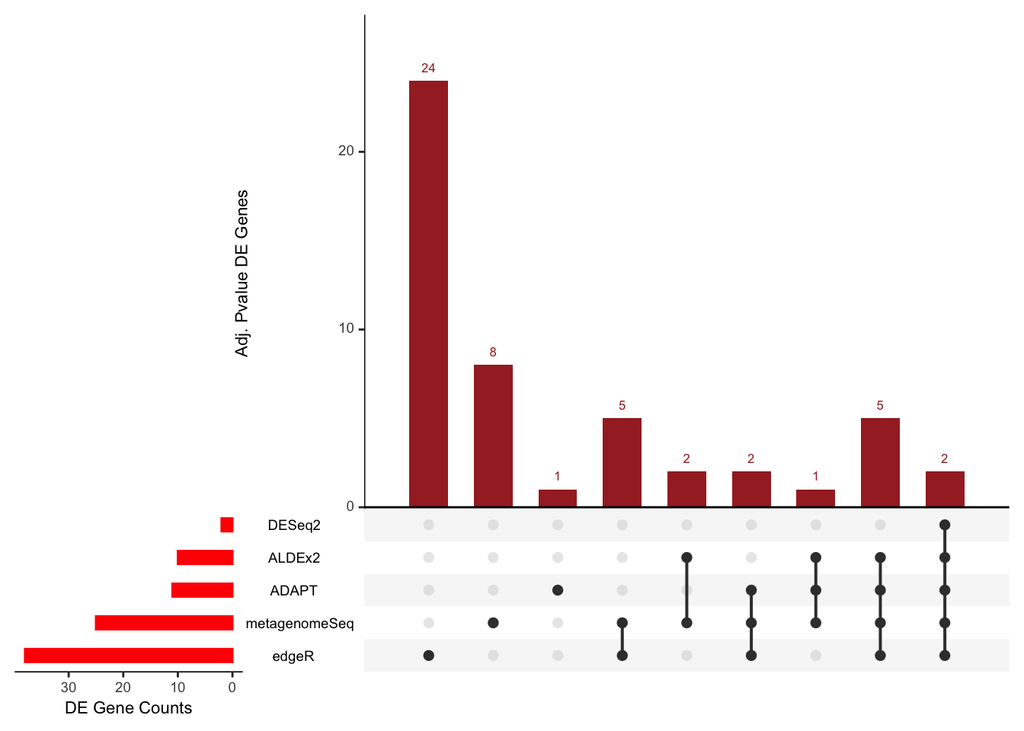

```r
print(ecc_saliva_DA$Control_vs_Case$upset_plot)
```

## 4.2 Venn Diagram from Differential abundance

Venn Diagram is plotted for each differential abundance comparison respectively.

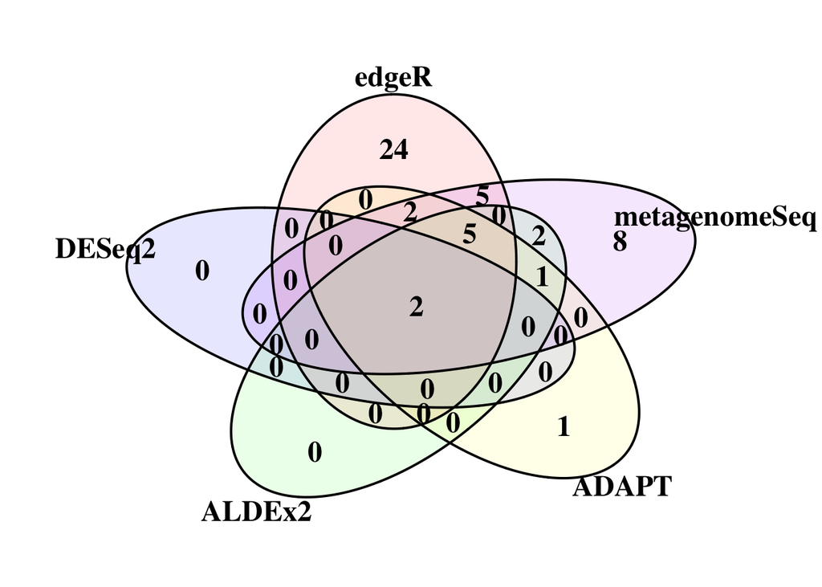

```r
library(grid)
grid.newpage()
grid.draw(ecc_saliva_DA$Control_vs_Case$VennDiagram)
```

# 5 Plotting functions

Creates Five different plots and saves them as pdf files. (1) Alpha diversity - Shannon, (2) Beta diversity – Principal Coordinate Analyses (PcoA), (3) rare faction curve and (4) Scaled plot at taxa level 5) Bi-directional plots. These plots are generated using the ggplot2 package (Wickham, 2016).

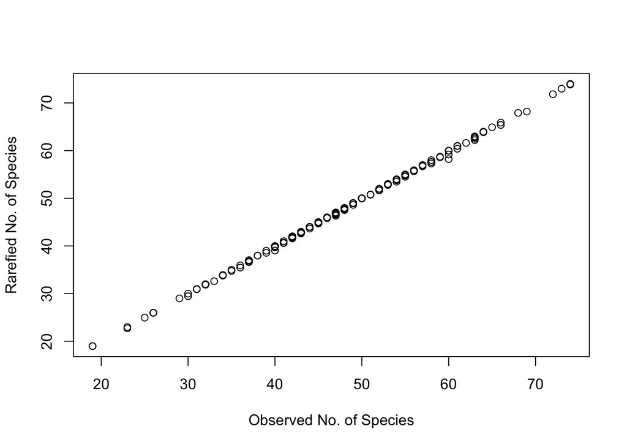

```
## Running comparison: Control_vs_Case
## Processing: Phylum for Control vs Case
```

```
## Completed: Phylum for Control vs Case
## Processing: Class for Control vs Case
```

```
## Completed: Class for Control vs Case
## Processing: Order for Control vs Case
```

```
## Completed: Order for Control vs Case
## Processing: Family for Control vs Case
```

```
## Completed: Family for Control vs Case
## Processing: Genus for Control vs Case
```

```
## Completed: Genus for Control vs Case
## Running comparison: Case_vs_Control
## Processing: Phylum for Case vs Control
```

```
## Completed: Phylum for Case vs Control
## Processing: Class for Case vs Control
```

```
## Completed: Class for Case vs Control
## Processing: Order for Case vs Control
```

```
## Completed: Order for Case vs Control
## Processing: Family for Case vs Control
```

```
## Completed: Family for Case vs Control
## Processing: Genus for Case vs Control
```

```
## Completed: Genus for Case vs Control
```

```r
ecc_saliva_plots <- OTUs_plots(ecc_saliva_build_OTU_counts)
```

## 5.1 rarefaction curve

A rarefaction curve is a simple graph that shows how many different microbial species you find as you sequence more and more DNA from a sample.

- Different sequencing depths shows unfair comparison
- Rarefaction normalizes all samples to same depth
- Now one can compare diversity between samples

Rarefaction curves help ensure one have sequenced enough to capture the true diversity in your samples and allow fair comparisons between different samples or studies.

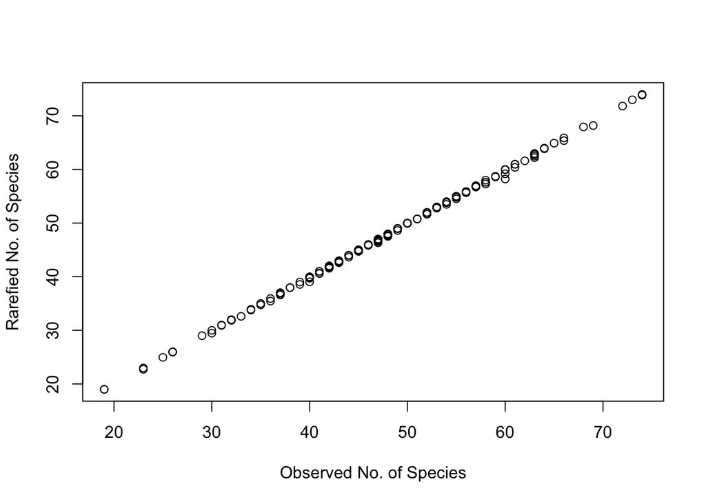

```
## Running comparison: Control_vs_Case
## Processing: Phylum for Control vs Case
```

```
## Completed: Phylum for Control vs Case
## Processing: Class for Control vs Case
```

```
## Completed: Class for Control vs Case
## Processing: Order for Control vs Case
```

```
## Completed: Order for Control vs Case
## Processing: Family for Control vs Case
```

```
## Completed: Family for Control vs Case
## Processing: Genus for Control vs Case
```

```
## Completed: Genus for Control vs Case
## Running comparison: Case_vs_Control
## Processing: Phylum for Case vs Control
```

```
## Completed: Phylum for Case vs Control
## Processing: Class for Case vs Control
```

```
## Completed: Class for Case vs Control
## Processing: Order for Case vs Control
```

```
## Completed: Order for Case vs Control
## Processing: Family for Case vs Control
```

```
## Completed: Family for Case vs Control
## Processing: Genus for Case vs Control
```

```
## Completed: Genus for Case vs Control
```

```r
ecc_saliva_plots <- OTUs_plots(ecc_saliva_build_OTU_counts)
```

## 5.2 Alpha Diversity

Alpha Diversity is present using Phyloseq Shannon index method; It represents within one sample microbiome diversity (e.g., one person’s gut microbiome). Measures both richness and evenness of microbial species. Single-sample metric (unlike beta diversity which compares between samples). Higher values generally indicate healthier, more stable microbiomes.

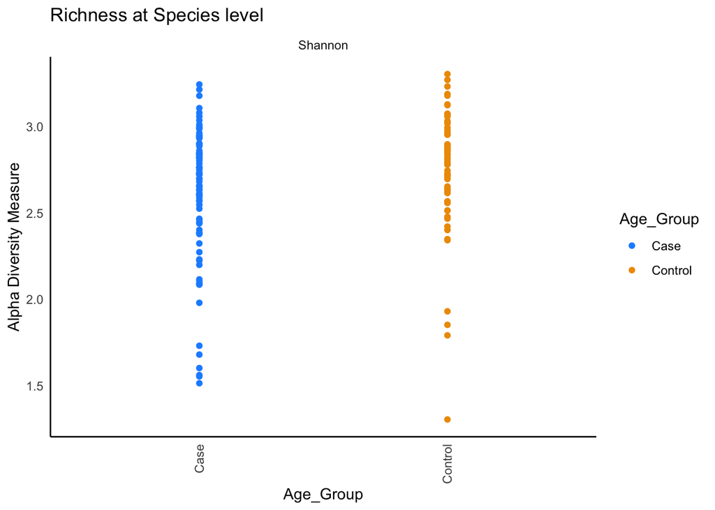

```r
print(ecc_saliva_plots$AlphaDiv$tax_level)
```

## 5.3 Beta Diversity/Principle Coordinates Analysis

Beta diversity or Principle Coordinates analysis represents difference among groups and diversity of microbiome and among samples. It’s essential for understanding how microbiomes vary across individuals, conditions, or treatments.

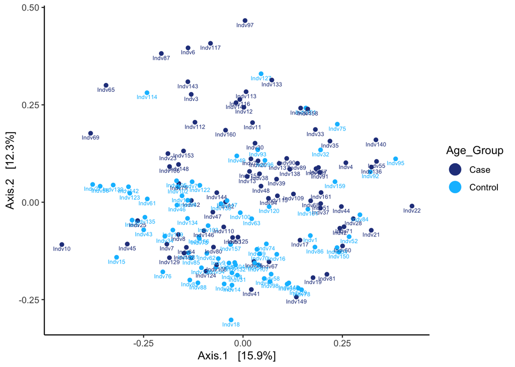

```r
print(ecc_saliva_plots$BetaDiv)
```

## 5.4 Bidirectional Plot

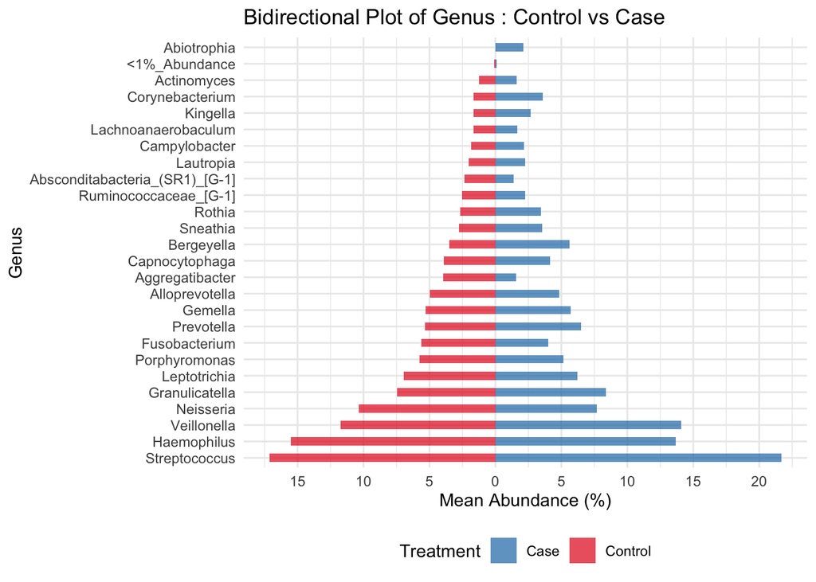

```r
print(ecc_saliva_plots$all_comparisons_results$Control_vs_Case$Genus_plot)
```

- High abundance and High prevalence increase
  - Beneficial bacteria expanding after prebiotic treatment
- Higher abundance and Lower prevalence
  - Pathogen blooming in susceptible individuals only
- Lower abundance and Higher prevalence
  - Opportunistic bacteria colonizing stressed communities
- Lower abundance and Lower prevalence
  - Sensitive bacteria dying off after antibiotic treatment

# 6 Citing results that use `ConsesnsusMetaDA`

When using this package, please cite ConsesnsusMetaDA as follows and all methods used in your analysis.

For consensus DE:

```r
#citation("ConsesnsusMetaDA")
```

- When using DESeq2 (also check package reference suggestions)
  - Love, M.I., Huber, W., Anders, S. Moderated estimation of fold change and dispersion for RNA-seq data with DESeq2 Genome Biology 15(12):550 (2014)
- When using edgeR (also check package reference suggestions)
  - Robinson MD, McCarthy DJ and Smyth GK (2010). edgeR: a Bioconductor package for differential expression analysis of digital gene expression data. Bioinformatics 26, 139-140
  - McCarthy DJ, Chen Y and Smyth GK (2012). Differential expression analysis of multifactor RNA-Seq experiments with respect to biological variation. Nucleic Acids Research 40, 4288-4297
- When using ALDEx2 (also check package reference suggestions)
  - Fernandes, A. D., Macklaim, J. M., Linn, T. G., Reid, G., & Gloor, G. B. (2013). ANOVA-Like Differential Expression (ALDEx) Analysis for Mixed Population RNA-Seq. PLOS ONE, 8(7), e67019. doi:10.1371/journal.pone.0067019
- When using ADAPT (also check package reference suggestions)
  - Wang, M., Fontaine, S., Jiang, H., & Li, G. (2024). ADAPT: Analysis of Microbiome Differential Abundance by Pooling Tobit Models. Bioinformatics, 40(11). doi:10.1093/bioinformatics/btae661
- When using MetagenomeSeq (also check package reference suggestions)
  - Paulson JN, O. N., Braccia DJ, Wagner J, Talukder H, Pop M, Bravo HC (2013). metagenomeSeq: Statistical analysis for sparse high-throughput sequncing. Bioconductor package. Retrieved from http://www.cbcb.umd.edu/software/metagenomeSeq.